# Structural Complexity Indices

Mai Lazarus

Install needed packages if not already installed:

```r
is_inst <- function(pkg) {
  nzchar(system.file(package = pkg))
}

#Install the 'packman' library to easilly install additional libraries
if (!is_inst("pacman")) {install.packages("pacman")}

library("pacman")

p_load(dplyr, tidyverse, knitr ,tidyr, httr, reshape2, stringr, data.table,
       FD, corrplot, fractaldim, features, transport, pracma)
```

This script produces all structural complexity indices used in our study:

1. Structural diversity indices
2. Sky view factor indices
3. Common indices
4. Neighbors distance indices
5. Topographic position indices
6. FreeSpace index
7. EarthMovers index

For each of the groups, an Rmd file is sourced, where all functions are available. A short description of the essence and calculation of each of the aforementioned indices groups is also in the Rmd file. For full description please refer to the manuscript.

**Data**

The necessary data for all functions should include 3 variables:

- Depth values along the bottom profile
- Their order, i.e. an acending sequence of numbers corresponding to the measurements
- An identification variable distinct for each bottom profile

For functions that require more data explanations are provided.

Step 1: import data Here is an example data, including 9000 depth measurements from 50 ‘transects’

```r
data = read.csv("simulation_data.csv")
head(data)
```

```
##   ID     depth point
## 1  1 -15.42941     1
## 2  1 -15.52010     2
## 3  1 -16.72426     3
## 4  1 -16.59976     4
## 5  1 -15.20889     5
## 6  1 -16.73757     6
```

Step 2: calculate structural complexity indices

**1. Structural diversity indices:**

Calculate structural diversity (FD) indices: Here, 3 more arguments other than ‘data’ are required:

1. transect_length - the length of the transect, in m.
2. search distance - the distance in meters in which local extrama are searched from each focal measurement.
3. traits - a vector with the names of elements traits chosen for the calculation of structural diversity.

Three types of plots are created, presenting the bottom profile: For each transect, side by side:

1. Local extrema of all levels.
2. Structural elements within the profile, distinguished by colors.
3. A single plot presenting the correlations among structural elements traits.

*Here, plots 1,2 are shown only for bottom profile number 1. To show the results for all bottom profiles, change the chunks’ settings.

Please refer to ‘Structural diversity functions.Rmd’ for more details.

```r
FD_indices = indices_calc_fun(data,
                              transect_length = 25,
                              search_distance = 0.75,
                              traits = c("rugosity","vr","max_slope"))
```

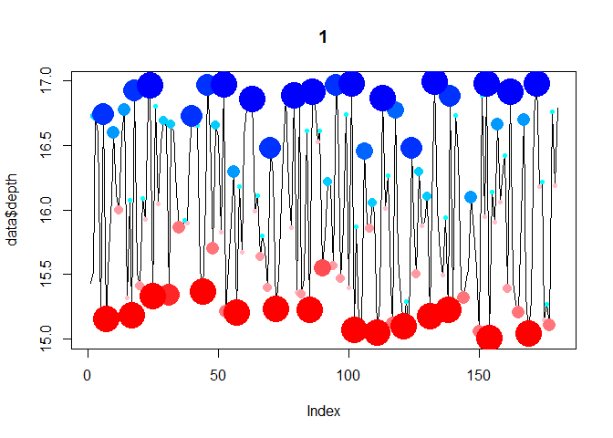

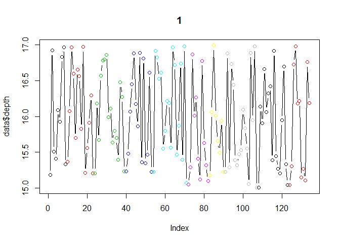

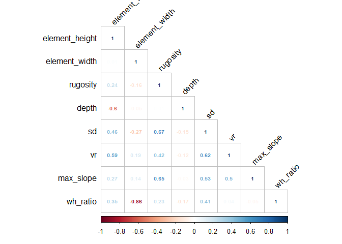

```r
head(FD_indices)
```

```
##   ID FunRichness FunEvenness FunDispersion FunOriginality FunDistinct
## 1  1  0.03957480   0.9242369     0.3584426      1.0994272    12.56546
## 2  2  0.04878088   0.9194211     0.3811884      0.8511679    11.61466
## 3  3  0.03745877   0.9156723     0.3374896      1.5791781    12.85666
## 4  4  0.05429278   0.9744112     0.3630204      0.5037753    11.65828
## 5  5  0.03133103   0.9424821     0.3480476      0.5478100    11.32105
## 6  6  0.02442615   0.8977883     0.3510118      0.6511968    12.56106
##   FunIrregular FunSingular
## 1     8.596940   10.867352
## 2     9.291000    9.797663
## 3     9.426537   11.003918
## 4     9.154328    9.695327
## 5     8.318924    9.442034
## 6     8.361367   10.554403
```

**2. Sky view factor indices**

Calculate Sky view factor (SkyView) indices: Here, 3 additional arguments are required: 1. ‘radius_length’ - the length of the arch’s radius.

2. ‘threshold’ - the amount of angles to extract (%) for the calculation, to avoid the overriding effects of flat areas with low angle values.
3. ‘edges_to_remove’ - the distance to remove from each of the transects’ ends, as the profile is unknown beyonf the transects’ boundaries.

For full description, refer to ‘Sky view factor.Rmd’ file and the manuscript.

```r
SkyViewFactor = apply_svf_fun(data, radius_length = 2.5, threshold = .3, transect_length = 25, edges_to_remove = 2.5)

head(SkyViewFactor)
```

```
## # A tibble: 6 x 3
## # Groups:   ID [6]
##      ID SkyView SkyView_sd
##   <int>   <dbl>      <dbl>
## 1     1    126.       12.9
## 2     2    126.       13.3
## 3     3    126.       13.4
## 4     4    125.       12.7
## 5     5    126.       13.1
## 6     6    126.       12.0
```

**3. Common indices**

Calculate common indices indices:

```r
common_indices = common_fun(data)
head(common_indices)
```

```
## # A tibble: 6 x 8
##      ID Rugosity    SD VerRelief    Slope FractalDim Curvature mean_depth
##   <int>    <dbl> <dbl>     <dbl>    <dbl>      <dbl>     <dbl>      <dbl>
## 1     1     5.08 0.603      1.99 0.00169        1.19     0.687      -16.0
## 2     2     4.78 0.564      1.98 0.000808       1.18     0.695      -16.1
## 3     3     5.53 0.581      1.98 0.000187       1.24     0.508      -16.0
## 4     4     4.49 0.542      1.98 0.000960       1.15     0.529      -16.0
## 5     5     5.43 0.584      1.98 0.000277       1.22     0.542      -16.0
## 6     6     4.87 0.571      1.97 0.00131        1.20     0.472      -16.0
```

**4. Neighbors distance indices**

Calculate Neighbors distance indices indices:

```r
neighbors_indices = neighbors_indices_fun(data)
head(neighbors_indices)
```

```
## # A tibble: 6 x 3
##      ID ConsecutiveHeightDiff Neighbors_dist
##   <int>                 <dbl>          <dbl>
## 1     1                 11.5            4.88
## 2     2                 10.7            4.58
## 3     3                 12.0            5.39
## 4     4                  9.97           4.28
## 5     5                 11.7            5.28
## 6     6                 10.8            4.70
```

**5. Topographic position indices - Max concavity/convexity**

Calculate Max concavity/convexity indices indices:

```r
Max_concave_convex_indices = Max_concave_convex_fun(data)
head(Max_concave_convex_indices)
```

```
## # A tibble: 6 x 3
##      ID Max_convexity Max_concavity
##   <int>         <dbl>         <dbl>
## 1     1         -30.4         -33.6
## 2     2         -30.3         -33.7
## 3     3         -30.3         -33.4
## 4     4         -30.4         -33.6
## 5     5         -30.6         -33.4
## 6     6         -30.1         -33.3
```

**6. FreeSpace index**

Calculate FreeSpace index:

```r
FreeSpace_index = FreeSpace_fun(data)
head(FreeSpace_index)
```

```
## # A tibble: 6 x 2
##      ID FreeSpace
##   <int>     <dbl>
## 1     1      180.
## 2     2      191.
## 3     3      184.
## 4     4      181.
## 5     5      177.
## 6     6      170.
```

**7. EarthMovers index**

Calculate EarthMovers indices:

```r
EarthMovers_data = wass_fun(data)
head(EarthMovers_data)
```

```
## # A tibble: 6 x 2
##      ID earth_movers
##   <int>        <dbl>
## 1     1        0.675
## 2     2        0.491
## 3     3        0.602
## 4     4        0.563
## 5     5        0.603
## 6     6        0.663
```

Join all indices data:

```r
complexity_indices = Reduce(function(x, y) merge(x, y, by = "ID", all = TRUE), list(FD_indices, SkyViewFactor, common_indices, neighbors_indices, Max_concave_convex_indices, FreeSpace_index, EarthMovers_data))
head(complexity_indices)
```

```
##   ID FunRichness FunEvenness FunDispersion FunOriginality FunDistinct
## 1  1  0.03957480   0.9242369     0.3584426      1.0994272    12.56546
## 2  2  0.04878088   0.9194211     0.3811884      0.8511679    11.61466
## 3  3  0.03745877   0.9156723     0.3374896      1.5791781    12.85666
## 4  4  0.05429278   0.9744112     0.3630204      0.5037753    11.65828
## 5  5  0.03133103   0.9424821     0.3480476      0.5478100    11.32105
## 6  6  0.02442615   0.8977883     0.3510118      0.6511968    12.56106
##   FunIrregular FunSingular  SkyView SkyView_sd Rugosity        SD VerRelief
## 1     8.596940   10.867352 125.5727   12.93577 5.078714 0.6033508  1.989081
## 2     9.291000    9.797663 126.2883   13.29227 4.782563 0.5641584  1.980405
## 3     9.426537   11.003918 126.3218   13.39465 5.532578 0.5812697  1.983029
## 4     9.154328    9.695327 125.4440   12.68900 4.485257 0.5415926  1.980193
## 5     8.318924    9.442034 126.1619   13.09733 5.429540 0.5838851  1.977543
## 6     8.361367   10.554403 126.2387   12.04207 4.873466 0.5714027  1.972837
##          Slope FractalDim Curvature mean_depth ConsecutiveHeightDiff
## 1 0.0016853900   1.185176 0.6867692  -16.01239             11.514682
## 2 0.0008080024   1.178247 0.6952174  -16.07065             10.685106
## 3 0.0001868511   1.241674 0.5082090  -16.04322             11.977684
## 4 0.0009601248   1.154794 0.5291803  -16.02058              9.970592
## 5 0.0002767017   1.216865 0.5419718  -16.00359             11.669882
## 6 0.0013148844   1.201633 0.4722388  -15.96490             10.771449
##   Neighbors_dist Max_convexity Max_concavity FreeSpace earth_movers
## 1       4.881695     -30.36380     -33.62344  180.4695    0.6754946
## 2       4.583649     -30.32396     -33.67599  190.7540    0.4906233
## 3       5.393894     -30.34296     -33.41907  184.1567    0.6017657
## 4       4.281178     -30.43080     -33.60245  180.5799    0.5632170
## 5       5.284168     -30.56449     -33.43144  176.9518    0.6028883
## 6       4.698490     -30.14719     -33.30824  169.5334    0.6626838
```